# new_diversity_figures

Matt Doherty

2/25/2017

I’ve been working to improv my figures and analysis for the paper and future presenations. Below I show the results from doing wilcox/kruskal tests across phyla and OTUs and then adjusting the p values using the “BH method”.

### Phyla

No phyla were significantly different after multiple corrections, but there are some phyla that appear enriched in non-remitters compared to remitters and vice versa.

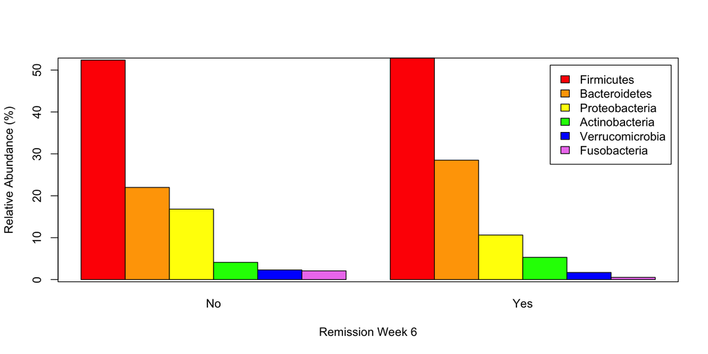

This is a base plot showing the differences in phylum by Remission at Week 6, but I didn’t like the look of it and talked to Nick and Amanda, who helped me with ggplot-ing it.

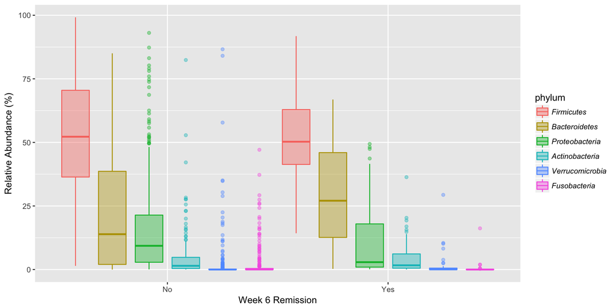

I think the ggplot look much better, but not sure if it is the best way to show the comparison so I tried showing each phylum by remission status at week 6.

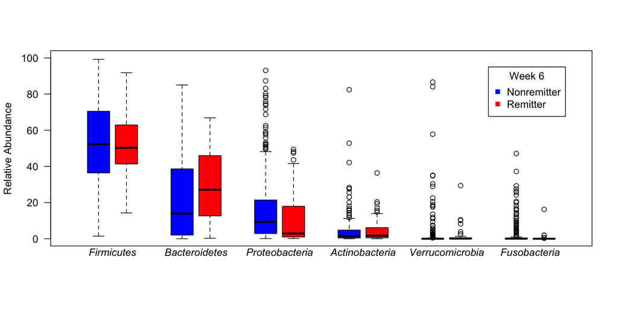

This base plot might be my preffered way to show the data so far.

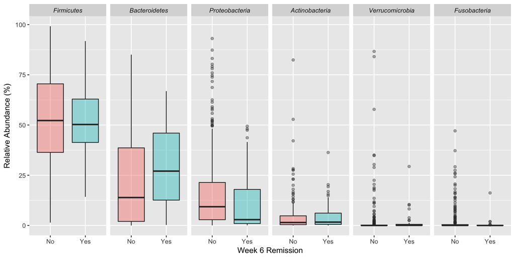

Almose the same thing with ggplot.

### OTUS

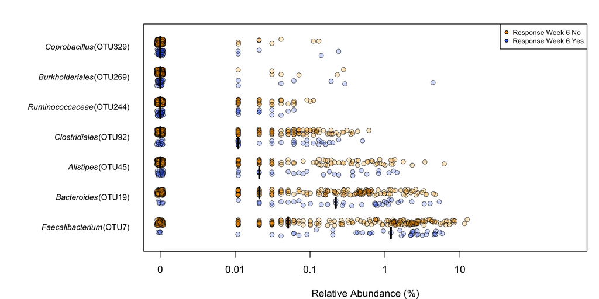

The old familiar base plot stripcharts might still be my preferred way of veiwing the otus

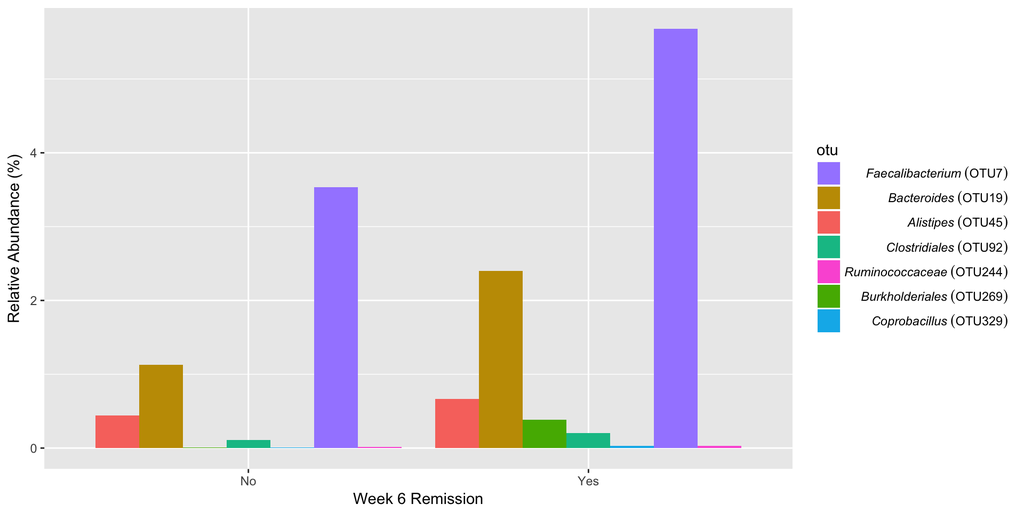

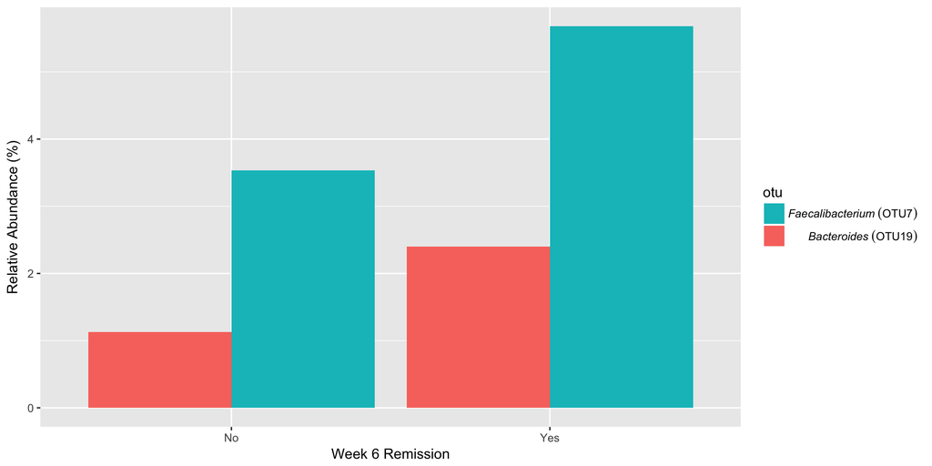

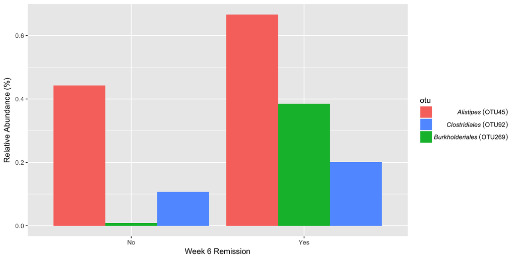

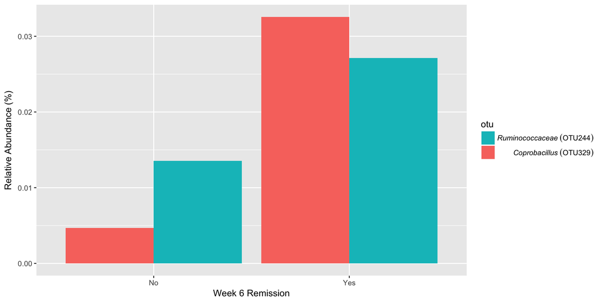

These show the OTUs by mean relative abundance together and then broken down by relative abundance to show the differences. This seems like overkill, but the breakdown might be good for supp figures.

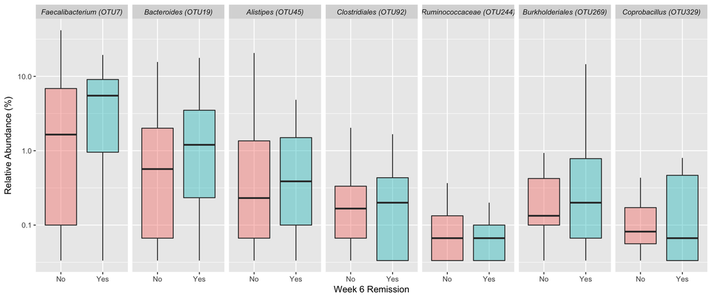

In this plot zero values have been removed due to the log scale on the y axis, so i am not sure if it best represents the data.